# 04_UML_Building_Blocks

## Будівельні блоки UML.

**До будівельних блоків UML** відносяться:

- Предмети/Елементи (Things/Elements).
- Відносини (Relationships).
- Діаграми (Diagrams).

**Предмети/Елементи** – сутності чи об’єкти реального світу:

- Структурні (Structural).
- Поведінкові (Behavioral).
- Групуючі (Grouping).
- Анотаційні (Annotational).

**Структурні елементи** використовуються для опису статичної частини моделі. Усі структурні елементи UML пов’язані з фізичною частиною системи. Це іменники UML (клас, об’єкт, інтерфейс, співпраця, варіант використання, компонент, вузол).

**Клас (Class)** – набір об’єктів, мають схожі обов’язки. Також є абстрактний клас, функції якого не визначені.

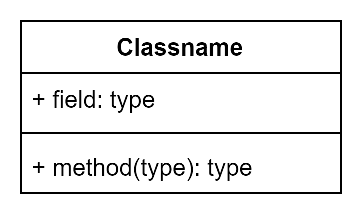

**Об’єкт (Object)** - сутність, яка використовується для опису поведінки та функцій системи.

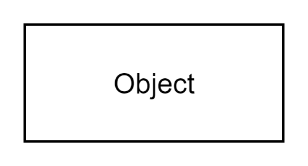

**Інтерфейс (Interface)** визначає набір операцій, що визначають відповідальність класу.

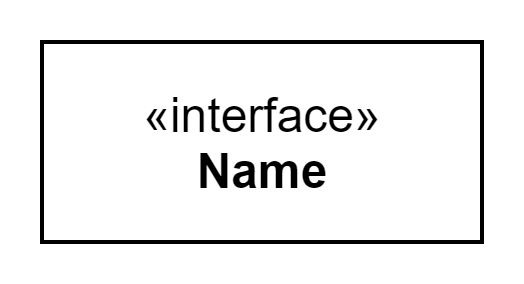

**Співпраця (Collaboration)** визначає взаємодію між елементами.

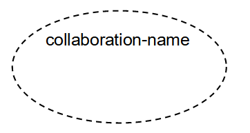

**Варіант використання (Use Case)** – набір дій, які виконує система для певної мети.

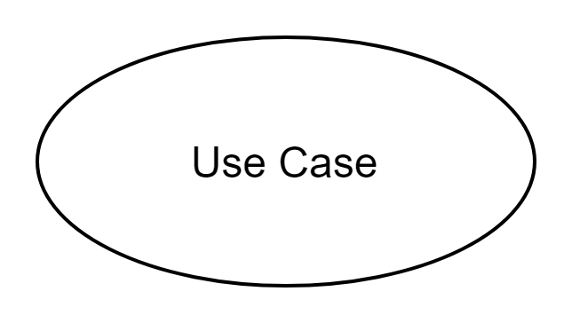

**Актор (Actor).** Використовується в Use Case діаграмах. Позначає сутність, що взаємодіє із системою.

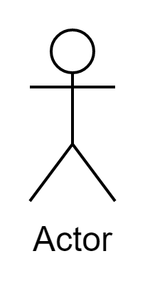

**Компонент (Component)** визначає фізичну частину системи.

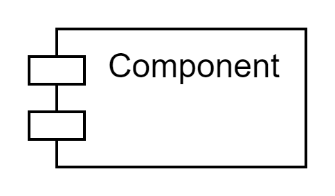

**Вузол (Node)** – фізичний елемент, що існує під час виконання (мережа, сервер, маршрутизатор тощо).

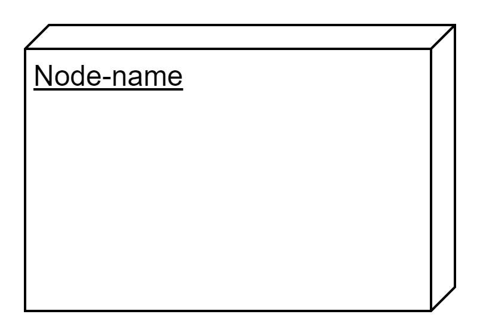

**Поведінкові елементи** - це дієслова моделі UML, такі як взаємодії, дії та кінцеві автомати. Використовуються для подання поведінки системи.

**Кінцевий автомат (State Machine).** Визначає послідовність станів, які об’єкт відбувається у життєвому циклі розробки програмного забезпечення. Веде облік кількох різних станів компонента системи.

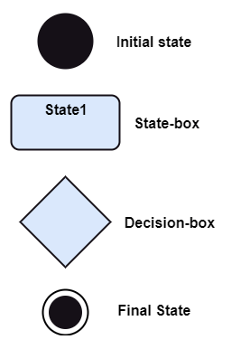

**Діаграма діяльності (Activity diagram)** використовується для представлення різних дій, виконуваних різними компонентами системи. Складається з початкового стану, кінцевого стану, вікна рішення та позначення дії.

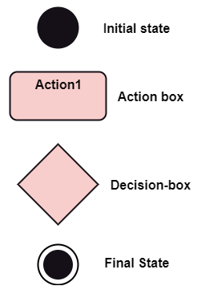

**Діаграми взаємодії (Interaction diagrams)** використовуються для візуалізації потоку повідомлень між різними компонентами системи.

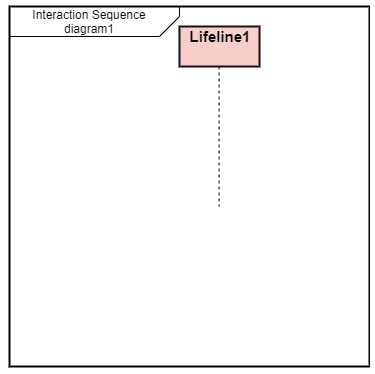

**Групуючі елементи**

**Пакет (package)**, який використовується для угруповання семантично пов’язаних елементів моделювання в єдину зв’язкову одиницю.

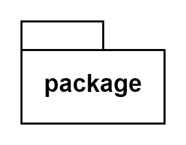

**Анотаційні елементи.** Механізм, який фіксує примітки, описи та коментарі елементів моделі UML.

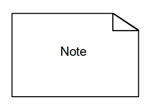

**Відносини UML** дозволяють показати на моделі, як два або більше елементів пов’язані один з одним. Відносини UML дозволяють зафіксувати значні зв’язки між елементами. Показується, як кожен елемент пов’язаний один з одним і як ця асоціація визначає функціональність програми.

**Відносини UML:**

- Відносини асоціації (Association relationship).
- Відносини залежності (Dependency relationship).
- Відносини узагальнення (Generalization relationship).
- Відносини реалізації (Realization relationship).

**Відносини асоціації** - набір посилань, які поєднують елементи моделі UML. Визначають, скільки об’єктів бере участь у цих відносинах. Показують, скільки елементів бере участь у конкретній взаємодії. Описують відносини елементів з обох боків.

**Відносини залежності** - відносини, у яких зміна цільового елемента впливає на вихідний елемент, тобто вихідний елемент залежить від цільового елемента. Відображає залежність одного об’єкта від іншого.

**Відносини узагальнення** відображають відносини між загальним предметом (батьківський клас чи суперклас) та певним типом цього предмета (дочірній клас чи підклас). Використовуються для опису успадкування.

**Відносини реалізації** - семантичний вид відносин між двома елементами, де один визначає поведінку, що має виконуватися, а інший реалізує цю поведінку. Існують в інтерфейсах.

**UML конектори** - конектори (з’єднувачі) зв’язують елементи разом і представлені у вигляді ліній на схемах, що показують, як елементи співвідносяться один з одним. У порівнянні з природними мовами, якщо елементи є іменниками, з’єднувачами є дієслова, які описують, як іменники співвідносяться один з одним.

**Асоціація** має на увазі, що два елементи моделі мають відношення, що зазвичай реалізується як змінна екземпляра в одному або обох класах.

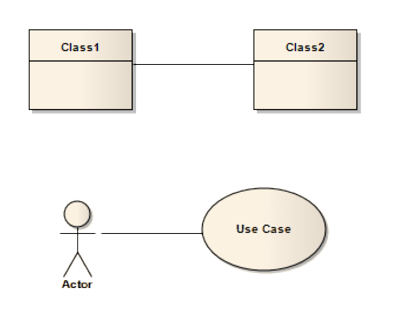

**Відносини залежності** використовуються для моделювання широкого діапазону залежних відносин між елементами моделі у схемах варіантів використання, дій та структурних схем і навіть між самими моделями.

**Узагальнення** використовується для позначення спадкування. Побудований від конкретного класифікатора до загального класифікатора, узагальнення передбачає, що джерело успадковує характеристики мети. Зазвичай використовують у діаграмах класів, компонентів, об’єктів, пакетів, варіантів використання.

**Реалізація.** Початковий об’єкт реалізує свій цільовий об’єкт. Конектори реалізації використовуються у діаграмах варіантів використання, компонентів, щоб висловити простежуваність та повноту моделі.

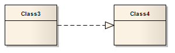

**Відношення використання** показує, що один елемент вимагає іншого для виконання певної взаємодії. Використовується у діаграмах варіантів використання для моделювання того, як суб’єкти використовують функціональні можливості системи (сценарії використання).

**«include»** вказує, що вихідний елемент включає функціональні можливості цільового елемента. Використовуються у моделях варіантів використання, щоб відобразити, що один варіант використання включає поведінку іншого.

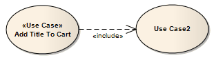

**«extend»** використовується, щоб вказати, що елемент розширює поведінку іншого, в основному в моделях варіантів використання, де один варіант використання (необов’язково) розширює поведінку іншого варіанта використання.

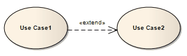

**Повідомлення.** Діаграми послідовності відображають робочий процес або активність у часі за допомогою повідомлень, що передаються від елемента до елемента. Ці повідомлення відповідають операціям та поведінці класу.

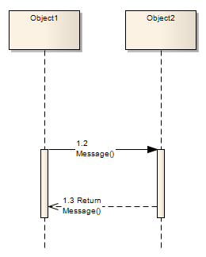

**Самостійне повідомлення** (Self-Message). Відображає новий процес або метод, викликаний в рамках операції лінії життя, що викликає. Це специфікація повідомлення, зазвичай, у вигляді діаграми послідовності.

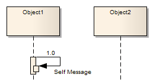

**Агрегація** – тип асоціації, який показує, що елемент містить чи складається з інших елементів. Використовується в моделях, щоб показати, як складніші елементи (агрегати) створюються з набору більш простих елементів (складових частин; наприклад, автомобіль із коліс, шин, двигуна тощо).

**Композиція** використовується для зображення елемента, що складається з дрібніших компонентів, як правило, в діаграмі класів або пакетів. Компонент – або екземпляр частини – може бути включений максимум в одну композицію за раз. Якщо композиція видаляється, зазвичай разом із нею видаляються її частини.

**Діаграми UML** – графічна реалізація моделей, що включає символи та текст:

- Структурні діаграми (Structure diagrams).
- Діаграми поведінки (Behavior diagrams).

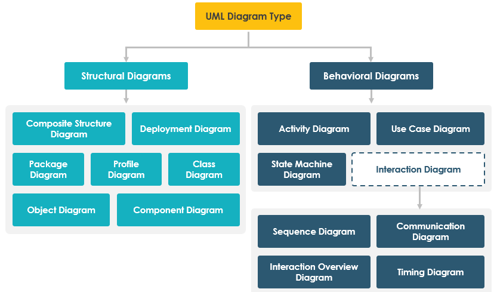

**Структурні діаграми** показують статичні частини системи та їх взаємозв’язок. Кожен елемент представляє конкретну концепцію і може включати абстрактні, реальні фактори і фактори реалізації.

**Діаграма класів** (Class diagram). Описує структуру системи, показуючи класи системи, їх атрибути, операції (або методи) та відносини між класами.

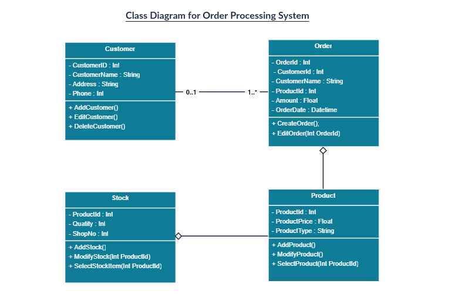

**Діаграма компонентів** (Component diagram). Візуалізує відносини, і навіть організацію між компонентами, що у системі.

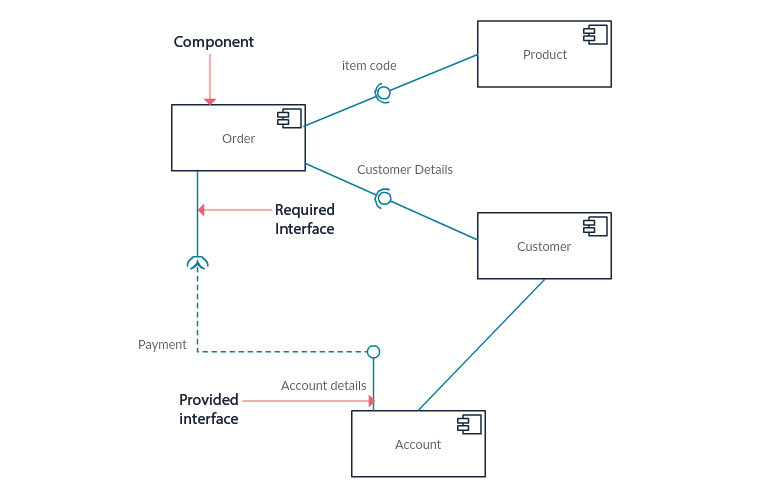

**Діаграма розгортання** (Deployment diagram). Візуалізує фізичне обладнання, на якому буде розгорнуто програмне забезпечення. Відображає статичне розгортання системи. Включає вузли та їхні стосунки.

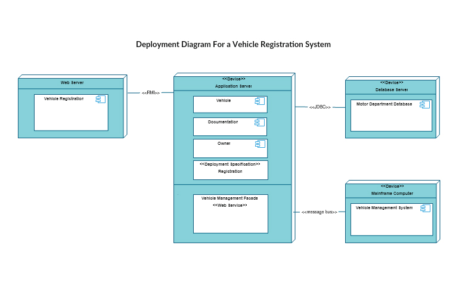

**Діаграма об’єкта** (Object diagram). Похідні від діаграм класів залежать від діаграм класів. Є екземпляром діаграми класів.

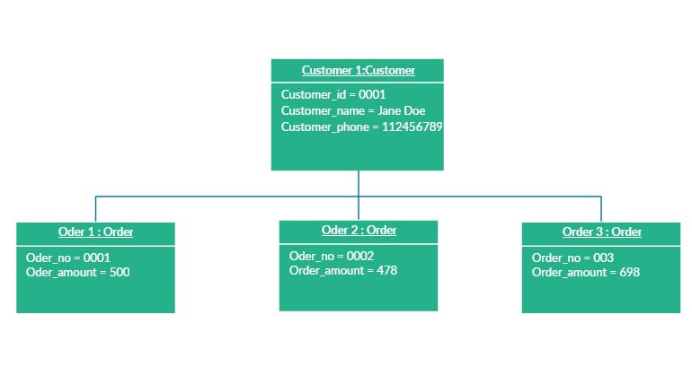

**Діаграма пакетів** (Package diagram). Показує залежність між різними пакетами в системі.

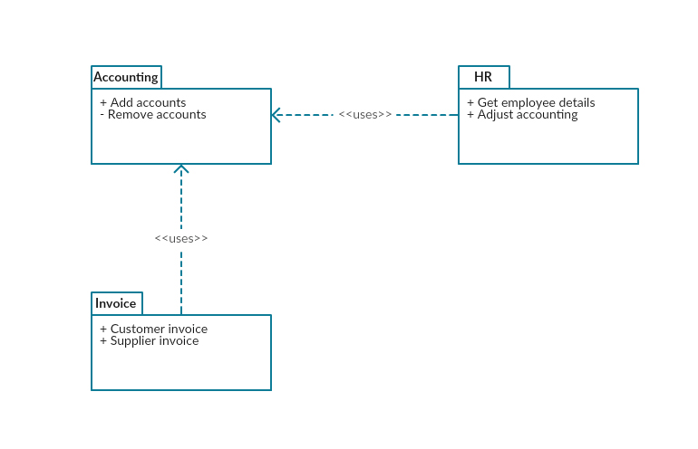

**Діаграма профілю** (Profile diagram). Механізм розширюваності шляхом додавання нових будівельних блоків, створення нових властивостей та визначення нової семантики для конкретної проблемної галузі.

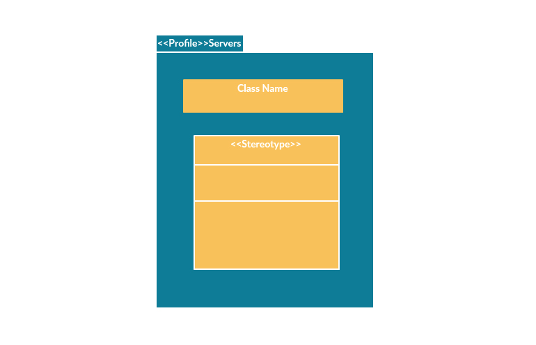

**Діаграма складової структури** (Composite structure diagram). Містить класи, інтерфейси, пакети та їхні стосунки. Забезпечує логічне представлення всієї чи частини програмної системи.

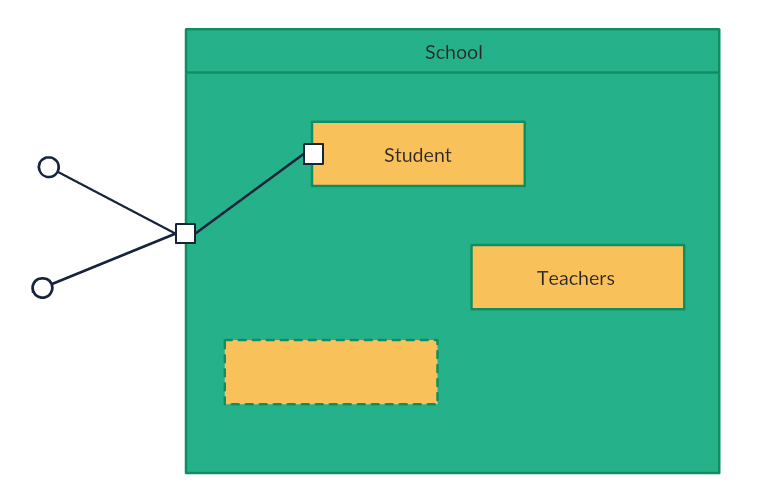

**Діаграми поведінки** показують, що має статися у системі. Описують, як об’єкти взаємодіють один з одним, створюючи систему, що функціонує.

**Діаграма діяльності** (Activity diagram). Моделює потік керування від однієї дії до іншої. Іноді використовується як альтернатива діаграмі кінцевих автоматів.

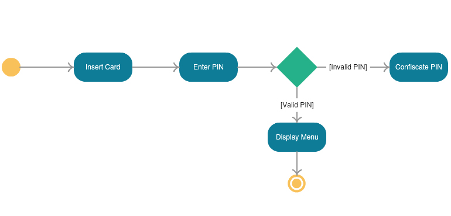

**Діаграма варіантів використання/прецедентів** (Use case diagram). Представляє функціональність системи за рахунок використання суб’єктів (акторів) та варіантів використання.

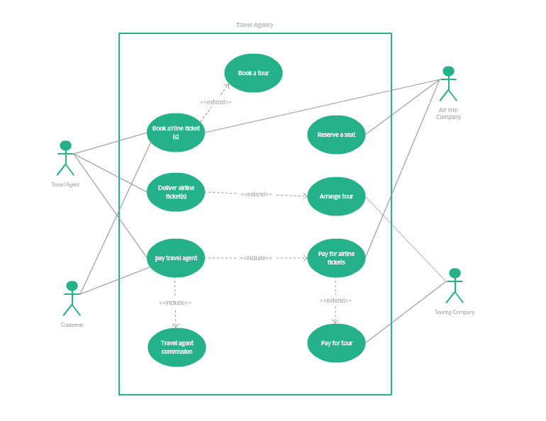

**Діаграма кінцевого автомата** (State machine diagram). Зображує поведінку системи за допомогою переходів кінцевого стану. Також відома як діаграма станів. Моделює динамічну поведінку класу у відповідь на зовнішні чинники впливу.

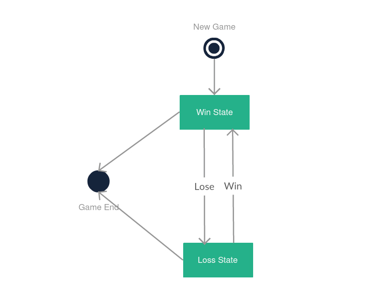

**Діаграми взаємодії** (Interaction Diagrams). Підклас діаграм поведінки, які наголошують на взаємодіях об’єктів, а також відображають потік між різними елементами варіанту використання системи. Показують, як об’єкти взаємодіють один з одним і як дані передаються усередині них. Складаються з діаграм комунікацій, огляду взаємодії, послідовності та часових діаграм.

**Діаграма послідовності** (Sequence diagram). Показує взаємодії між об’єктами з погляду повідомлень, якими обмінюються у часі. Визначає, як і як функції об’єкта перебувають у системі.

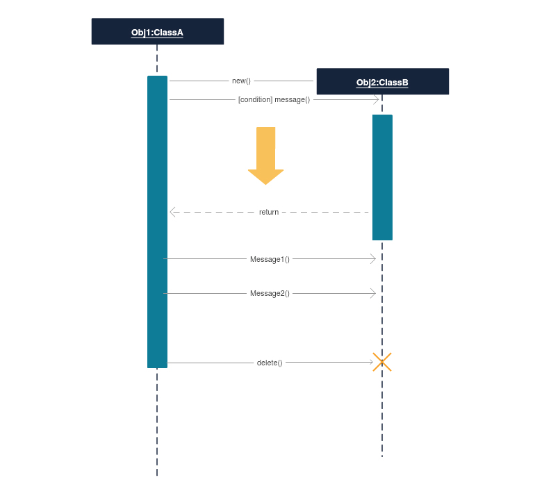

**Діаграма комунікацій** (Communication diagram). Показує обмін повідомленнями послідовності між об’єктами. Фокусується на об’єктах та їх відносинах. Описує статичну та динамічну поведінку системи.

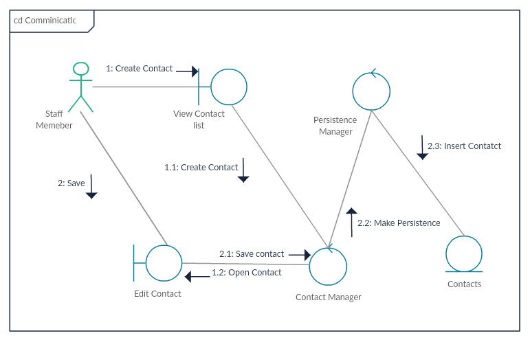

**Часова діаграма** (Timing diagram). Вид діаграми послідовності, який використовується для зображення поведінки об’єкта протягом певного періоду часу. Керує зміною стану та поведінки об’єкта, показуючи обмеження щодо часу та тривалості.

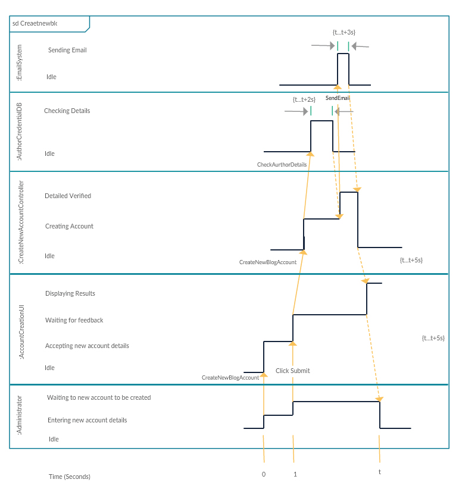

**Діаграма огляду взаємодії** (Interaction overview diagram). Комбінація діаграми дій та послідовності дій, що зображує послідовність дій, щоб спростити складні взаємодії до простих взаємодій.

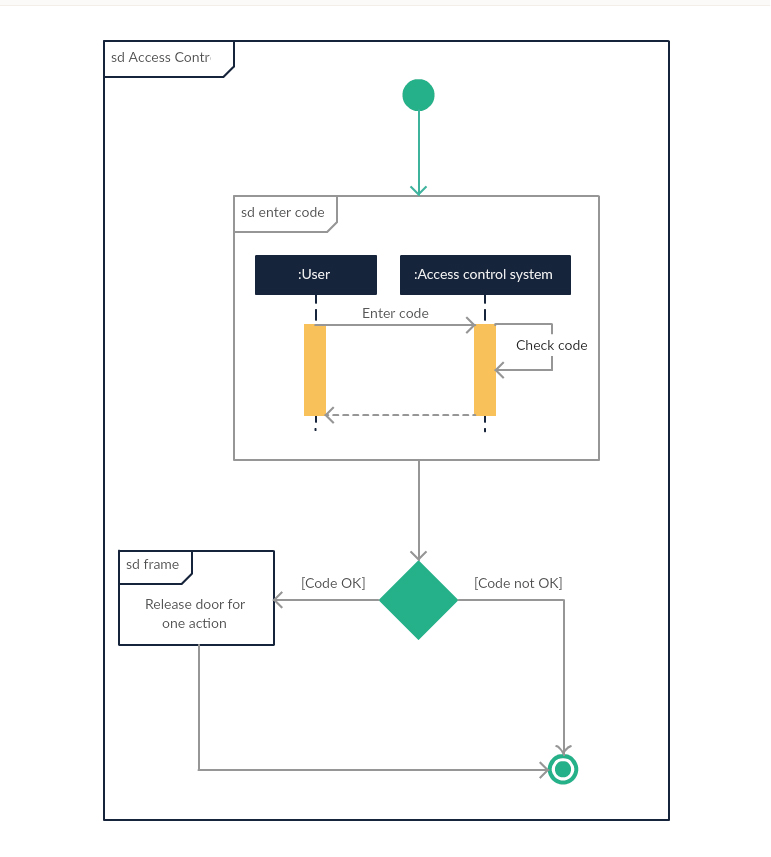